# reproducible_figures_assignment

Candidate number: 1051932

## What is the reproducibility crisis in science and should we care?

The reproducibility crisis is a name given to the current state of research, where other researchers are not able to produce similar results to the original study. In other words, the experimental and analytical methods outlined in the original study – when used by a different researcher – does not result in them reaching the same conclusions as the original researcher. This puts into question the reliability of the original study, and therefore its quality. Currently, lack of reproducible studies is the norm. Over 70% of researchers surveyed by Nature in 2016 reported to have failed in reproducing someone else’s – or their own – results (Baker, 2016). The reproducibility crisis should be cared out because it destabilises the foundations upon which knowledge is built. If results are not reproducible, conclusions are limited to a specific context, cannot be generalised to other scenarios. One major reason why researchers may not be able to reproduce results is poor documentation. Therefore some researchers cannot even reproduce their own data. They forget to note down exactly what steps were taken to collect and process data, so when coming back to their old studies, they find it difficult to interpret code and figures. Another reason is publication bias, towards fresh novel papers that vouch new and exciting findings, and against confirmation or negation of an already published article (Baker, 2016). This pushes researchers to focus more on producing new studies rather than reproducing older ones. A way forward, to ensure the reproducibility crisis is not exacerbated in the future, is to engage with open research. Whilst there can be additional costs for the researcher to make their papers open access, there are also incentives. Open access papers have increased reach due to fewer paywalls than subscription papers, making the chances of researchers accessing and reproducing studies more likely. Open access papers have been found to have more citations (McKiernan et al., 2016). Though, sharing research does not tackle the crisis at its core. Ensuring that methods are meticulously noted and are reproducible by others is pivotal. Researchers should actively design their experiments with reproducibility in mind. Whilst this may require more initial effort, research can be reconstructed with ease by future studies. The reproducibility crisis can be greatly discouraging for upcoming and established scientists alike (Fanelli, 2017). I believe that despite its pessimistic narrative, there is room for empowerment and inspiration. As mentioned before, reproducibility should be integral to design and implementation of research, such that a high standard of integrity and quality is maintained, so as to shift the norm of unreproducible research.

## Question 02: Create a figure using the Palmer Penguin dataset that is correct but badly communicates the data.

Focus on visual elements rather than writing misleading text on it. Provide the figure and explain your choices. 100-200 words

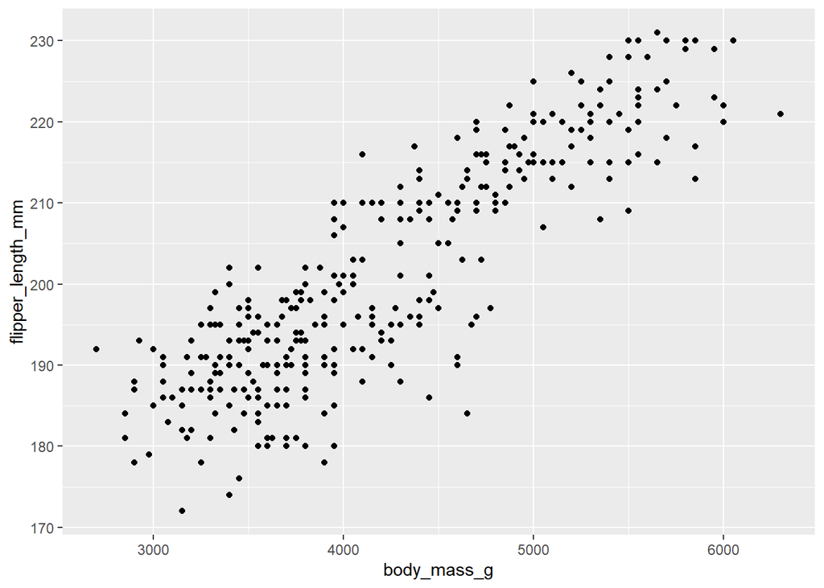

```r
library(palmerpenguins)
library(ggplot2)

penguins<-data.frame(palmerpenguins::penguins)

ggplot(penguins, aes(x=body_mass_g, y=flipper_length_mm))+ geom_point()
```

Question 03: Discuss how colour choice is important for communication in science figures and what considerations should be made 300-500 words

https://www.nature.com/articles/s41467-020-19160-7

Question 04: Run a statistical test on the Palmer Penguins dataset and produce a figure to explain it. Please create a new .rmd or .r file called penguin_assignment.r. Follow the subfolders structure in the notebooks, you may need to go through the notebooks again.

Use one of my files (See “Optional Template!” above) as a template if you like.

Your code should include the steps practised in the lab session:

Load the data Appropriately clean the data New: Run a statistical test Create a figure Save the figure As we have already covered a boxplot, please choose something different to plot.

Your figure should communicate the statistical test you have run. For example:

A T-test on bill depth length in Adelie vs Gentoo penguins, plot two overlapping histograms. A linear regression model between body mass and flipper length, plot a scatterplot with the linear model overlaid. Something else! You can use R script(s) and/or RMarkdown file as you prefer.

Your aim is that someone else can run your code and understand the steps involved.

Upload the code and figure file to Github, and provide the url to where it is on GitHub (please ensure anything identifying you is removed!)

Question 05: Download someone else’s example from Question 04. Provide the url of the work you are reviewing. In 250-500 words answer the following:

What elements of your partner’s code helped you to understand their data pipeline? Did you try to run it? Did it work? What suggestions would you make for improving their code to make it more understandable or reproducible, and why? If you needed to alter your partner’s figure using their code, do you think that would be easy or difficult, and why? Reflect on your own code and figure from Question 4 with reference to your partner’s work and also their review of yours. What improvements did they suggest, and do you agree? What did you learn about writing code for other people?